# hw03 - dplyr/ggplot II

# Task option 3 - The spread of GDP within the continents.

## A tibble

*Table 1. The spread of GDP within continents. For each country, min, max, mean and the difference between the minimum and maxiumum values has been calculated*

```
## # A tibble: 142 x 6
## # Groups:   continent [5]
##    continent country                  minGDP maxGDP meanGDP GDPdiff
##    <fct>     <fct>                     <dbl>  <dbl>   <dbl>   <dbl>
##  1 Africa    Algeria                   2449.  6223.   4426.   3774.
##  2 Africa    Angola                    2277.  5523.   3607.   3246.
##  3 Africa    Benin                      949.  1441.   1155.    492.
##  4 Africa    Botswana                   851. 12570.   5032.  11719.
##  5 Africa    Burkina Faso               543.  1217.    844.    674.
##  6 Africa    Burundi                    339.   632.    472.    292.
##  7 Africa    Cameroon                  1173.  2603.   1775.   1430.
##  8 Africa    Central African Republic   706.  1193.    959.    487.
##  9 Africa    Chad                       798.  1704.   1165.    906.
## 10 Africa    Comoros                    986.  1938.   1314.    951.
## # … with 132 more rows
```

## A plot from the tibble

The spread of GDP within the continents, as shown by plotting the mean GDP value for each country

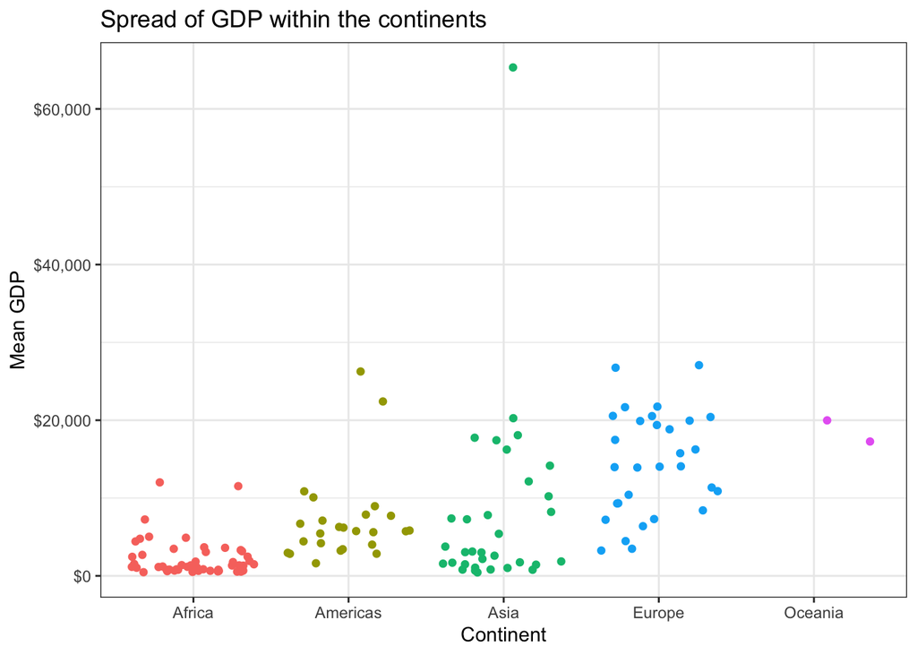

*Figure 1.* The spread of GDP within the continents, as shown by plotting the mean GDP value for each country

## What this figure/table show

**Table 1** shows the spread of GDP within each continent. In addition to the mean, minimum and maximum values of GDP for each country, the difference between the minimum and maximum GDP has also been calculated. This can be used to identify countries where there is greater economic inequality, i.e. the difference between min and max GDP is greater. **Figure 1** shows the spread of GDP within each continent by plotting the means of GDP per country. The most notable feature of this figure is the larger spread of GDP in Asia and Europe compared to Africa and the Americas.

# Task option 5 - How is life expectancy changing over time on different continents

## A tibble

*Table 2.* Life expectancy over time for each country

```
## # A tibble: 1,704 x 4
##    country     continent lifeExp  year
##    <fct>       <fct>       <dbl> <int>
##  1 Afghanistan Asia         28.8  1952
##  2 Afghanistan Asia         30.3  1957
##  3 Afghanistan Asia         32.0  1962
##  4 Afghanistan Asia         34.0  1967
##  5 Afghanistan Asia         36.1  1972
##  6 Afghanistan Asia         38.4  1977
##  7 Afghanistan Asia         39.9  1982
##  8 Afghanistan Asia         40.8  1987
##  9 Afghanistan Asia         41.7  1992
## 10 Afghanistan Asia         41.8  1997
## # … with 1,694 more rows
```

## A plot from the tibble

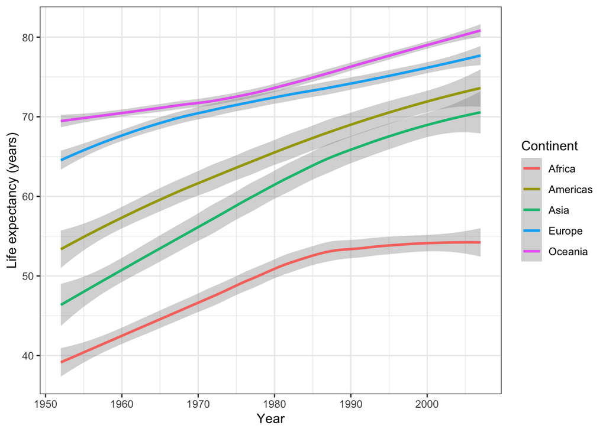

*Figure 2.* Change in life expectancy over time for each continent

## What this figure/table show

**Table 2** simply shows the life expectancy per year in each country. **Figure 2** then plots this data, fitting a line through the countries within each continent (grey areas indicate 0.95 confidence level). In addition to showing the increasing trend of life expectancy over time in all continents, it indicates there is a clear difference between the life expectancies between continents.

# Task option 6 - A country with an interesting story

## A tibble

A few preliminary data exploration steps were taken to identify a country with an interesting story

1. Plot all countries GDP per capita over time

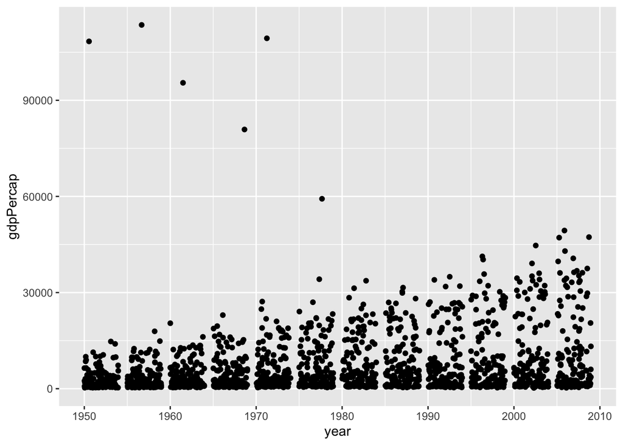

```r
(ggplot(gapminder, aes(year, gdpPercap)) + geom_jitter()) #To quickly explore the dataframe. There are some clear outliers here
```

2. From the above graph, there are clearly some countries that are outliers, so to identify which country they represented I made the following tibble:

```r
gapminder %>%
    filter(gdpPercap > 75000) #Kuwait has the highest GDP per capita from 1952-1972, but happens after?
```

```
## # A tibble: 5 x 6
##   country continent  year lifeExp    pop gdpPercap
##   <fct>   <fct>     <int>   <dbl>  <int>     <dbl>
## 1 Kuwait  Asia       1952    55.6 160000   108382.
## 2 Kuwait  Asia       1957    58.0 212846   113523.
## 3 Kuwait  Asia       1962    60.5 358266    95458.
## 4 Kuwait  Asia       1967    64.6 575003    80895.
## 5 Kuwait  Asia       1972    67.7 841934   109348.
```

3. After identifying Kuwait as the outlier in the data, I filtered the gapminder dataframe down to the following tibble:

```r
(Kuwait <- gapminder %>%
  filter(country == "Kuwait") %>%
  select(-"lifeExp"))
```

```
## # A tibble: 12 x 5
##    country continent  year     pop gdpPercap
##    <fct>   <fct>     <int>   <int>     <dbl>
##  1 Kuwait  Asia       1952  160000   108382.
##  2 Kuwait  Asia       1957  212846   113523.
##  3 Kuwait  Asia       1962  358266    95458.
##  4 Kuwait  Asia       1967  575003    80895.
##  5 Kuwait  Asia       1972  841934   109348.
##  6 Kuwait  Asia       1977 1140357    59265.
##  7 Kuwait  Asia       1982 1497494    31354.
##  8 Kuwait  Asia       1987 1891487    28118.
##  9 Kuwait  Asia       1992 1418095    34933.
## 10 Kuwait  Asia       1997 1765345    40301.
## 11 Kuwait  Asia       2002 2111561    35110.
## 12 Kuwait  Asia       2007 2505559    47307.
```

## A plot from the tibble

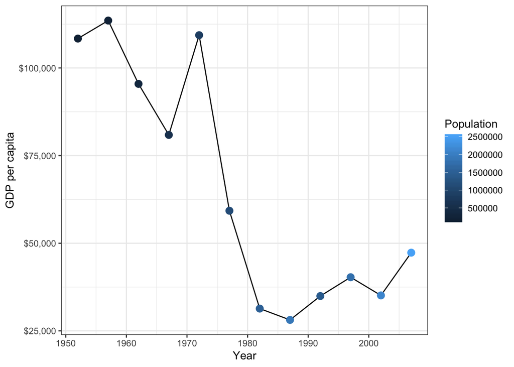

*Figure 3.* GDP per capita over and population change over time in Kuwait

## What this figure/table show

**Table 3** shows population and GDP per capita over time for Kuwait. In preliminary data exploration, Kuwait was an outlier in global GDP per capita values when plotted over time, hence why it was chosen to be a country with an interesting story. GDP per capita for Kuwait was expectionally higher than other countries, especially from 1952-1972. **Figure 3** goes on to plot the change in GDP per capita over time, which is characterised by large drop between 1972 and 1982. Over time population, which is indicated by colour, is increasing, following a general trend of decreasing GDP per capita, however this also follows a global trend of population increase over time.